# Estadística Multidimensional — Sesión 5

Densidad kernel y diagrama de dispersión

26158 · grupo 020-81 · lunes 24 de agosto de 2026

# 1 De dónde venimos

El sábado quedó una deuda. Vimos que el histograma **cambia de forma según `breaks`**: la misma variable parecía tres cosas distintas con 5, 20 y 60 clases. Y quedó dicho que el número de clases es una decisión del analista, no un hecho de los datos.

Hoy se resuelve esa deuda de dos maneras:

1. **La densidad kernel** reemplaza las cajas por algo continuo — pero, como veremos, no elimina la decisión: la traslada a un parámetro que **sí se puede escoger con un criterio**.
2. **El diagrama de dispersión** da el salto que la asignatura necesita: de una variable a **dos**.

# 2 El histograma, escrito como fórmula

Antes de reemplazarlo hay que ver qué es, exactamente. Un histograma con intervalos de ancho $h$ y origen $x_0$ estima la densidad en el punto $x$ así:

$$\hat f_{\text{hist}}(x) \;=\;
\frac{1}{n\,h}\;\#\{\, x_i \text{ en el mismo intervalo que } x
\,\}$$

Es decir: **cuenta cuántos datos caen en la caja** y divide por $n\,h$ para que el área total sea 1.

Tiene dos problemas, y el segundo es peor que el primero:

- **Depende de $h$** — el ancho de la caja. Eso ya lo vimos.
- **Depende de $x_0$** — dónde empieza la primera caja. Dos histogramas con el mismo ancho pero corridos medio intervalo pueden verse distintos. **Y eso no tiene ninguna justificación: el origen es arbitrario.**

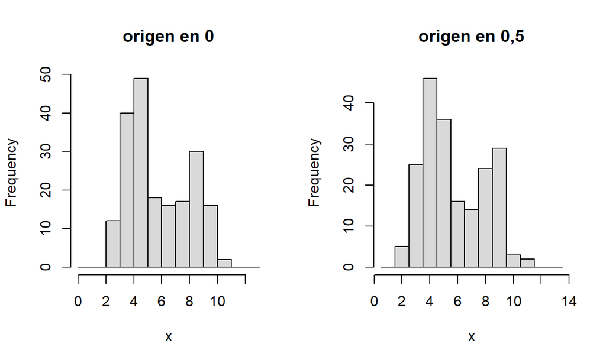

```r
set.seed(7)
x <- c(rnorm(120, 4, 1), rnorm(80, 8, 1.2))   # dos poblaciones, a propósito

par(mfrow = c(1, 2))
hist(x, breaks = seq(0, 13, by = 1),   main = "origen en 0", xlab = "x", col = "grey85")
hist(x, breaks = seq(0.5, 13.5, by = 1), main = "origen en 0,5", xlab = "x", col = "grey85")
```

```r
par(mfrow = c(1, 1))
```

**Mismo ancho, mismos datos, distinta lectura.** Ése es el defecto que la densidad kernel corrige.

# 3 La densidad kernel

## 3.1 La idea, antes que la fórmula

En vez de **contar** los datos que caen en una caja, se pone una **montañita** encima de cada dato y se **suman todas**. Donde haya muchos datos juntos, las montañitas se apilan y la curva sube. Donde haya pocos, la curva baja.

Nada de cajas, nada de origen arbitrario.

## 3.2 La fórmula

$$\boxed{\;\hat f_h(x) \;=\;
\frac{1}{n\,h}\sum_{i=1}^{n} K\!\left(\frac{x -
x_i}{h}\right)\;}$$

Pieza por pieza:

| Símbolo | Qué es | Quién lo decide |
| --- | --- | --- |
| $n$ | número de observaciones | los datos |
| $x_i$ | cada observación | los datos |
| $K(\cdot)$ | el **kernel**: la forma de la montañita | casi da igual |
| $h$ | el **ancho de banda**: qué tan ancha es | **usted, y decide todo** |

El kernel $K$ es una función que cumple dos condiciones:

$$K(u) \ge 0 \qquad\text{y}\qquad
\int_{-\infty}^{\infty} K(u)\,du = 1$$

es decir, **es en sí misma una densidad**. El más usado es el gaussiano:

$$K(u) =
\frac{1}{\sqrt{2\pi}}\,e^{-u^{2}/2}$$

## 3.3 Por qué el resultado también es una densidad

Esto conviene verlo, porque es la razón de que la fórmula lleve $\tfrac{1}{nh}$ adelante:

$$\int \hat f_h(x)\,dx
= \frac{1}{n h}\sum_{i=1}^{n} \int K\!\left(\frac{x-x_i}{h}\right) dx
= \frac{1}{n h}\sum_{i=1}^{n} h \int K(u)\,du
= \frac{1}{n}\sum_{i=1}^{n} 1 = 1$$

*(el cambio de variable $u = (x-x_i)/h$ trae el factor $h$, que se cancela)*

**Área 1 y valores no negativos: es una densidad legítima.** No es un dibujo bonito, es un estimador.

## 3.4 Verlo armarse

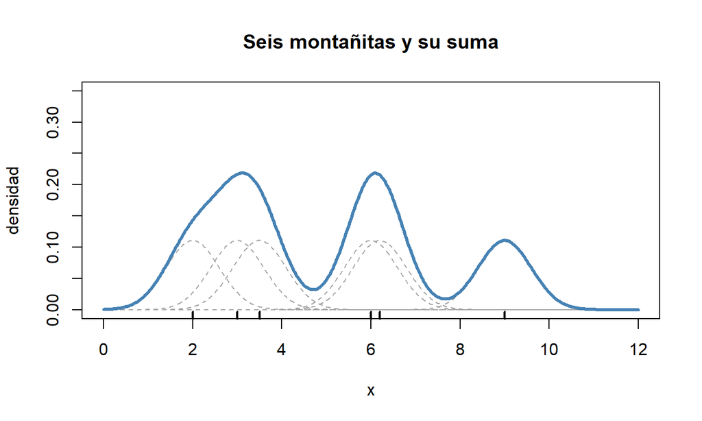

```r
xs <- c(2, 3, 3.5, 6, 6.2, 9)          # seis datos, para poder ver las montañitas
h  <- 0.6
rej <- seq(0, 12, length.out = 400)

plot(rej, rep(0, length(rej)), type = "n", ylim = c(0, 0.35),
     xlab = "x", ylab = "densidad",
     main = "Seis montañitas y su suma")

for (xi in xs) {                        # cada K((x - xi)/h) / (n*h)
  lines(rej, dnorm((rej - xi)/h) / (length(xs) * h), col = "grey65", lty = 2)
}
suma <- sapply(rej, function(z) sum(dnorm((z - xs)/h)) / (length(xs) * h))
lines(rej, suma, lwd = 3, col = "steelblue")
rug(xs, lwd = 2)
```

La línea gruesa es $\hat f_h$. Las punteadas son los seis sumandos.

## 3.5 El ancho de banda lo decide todo

$h$ es el análogo de `breaks`: no desapareció la decisión, **cambió de nombre**. Pero ahora sí hay criterios para escogerlo.

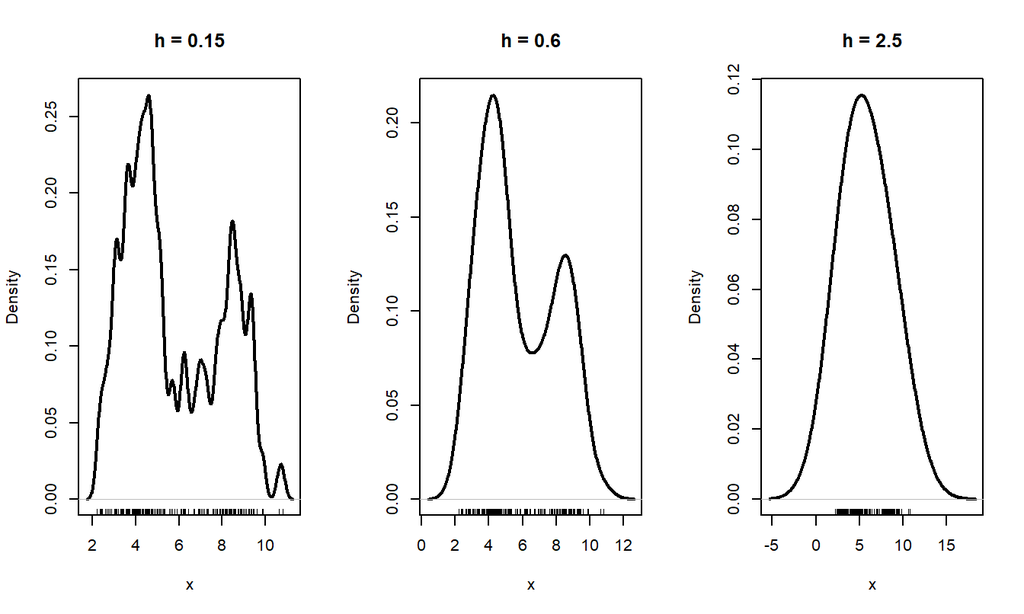

```r
par(mfrow = c(1, 3))
for (hh in c(0.15, 0.6, 2.5)) {
  plot(density(x, bw = hh), main = paste("h =", hh), xlab = "x", lwd = 2)
  rug(x)
}
```

```r
par(mfrow = c(1, 1))
```

- **$h$ pequeño** → poco sesgo, mucha varianza. Se ven picos que son ruido muestral.
- **$h$ grande** → poca varianza, mucho sesgo. Se pierde la estructura: **las dos poblaciones se funden en una**.

Es el compromiso sesgo–varianza, y aquí se ve con los ojos.

## 3.6 Cómo se escoge $h$ sin adivinar

La **regla de Silverman**, que es la que R usa por defecto:

$$h_{\text{Silverman}} \;=\; 0{,}9 \;
\min\!\left(s,\; \frac{\text{RIC}}{1{,}34}\right) n^{-1/5}$$

donde $s$ es la desviación estándar muestral y RIC el rango intercuartílico. El $\min$ está ahí para que un atípico no infle $s$ y ensanche la curva de más.

```r
h_manual <- 0.9 * min(sd(x), IQR(x)/1.34) * length(x)^(-1/5)
c(manual = h_manual, R = bw.nrd0(x))
```

```
#>    manual         R
#> 0.6886932 0.6886932
```

**Es una regla, no una verdad.** Está deducida suponiendo que los datos son normales, y estos —dos poblaciones— no lo son. Por eso conviene mirar dos o tres valores de $h$ antes de decidir.

> **Regla del curso:** todo gráfico de densidad que aparezca en un informe **declara su $h$**. Un `plot(density(x))` sin decir el ancho de banda es un gráfico sin unidades.

# 4 El salto: de una variable a dos

Hasta aquí, todo ha sido **una** variable a la vez. La asignatura se llama multidimensional por lo que viene ahora.

## 4.1 El diagrama de dispersión

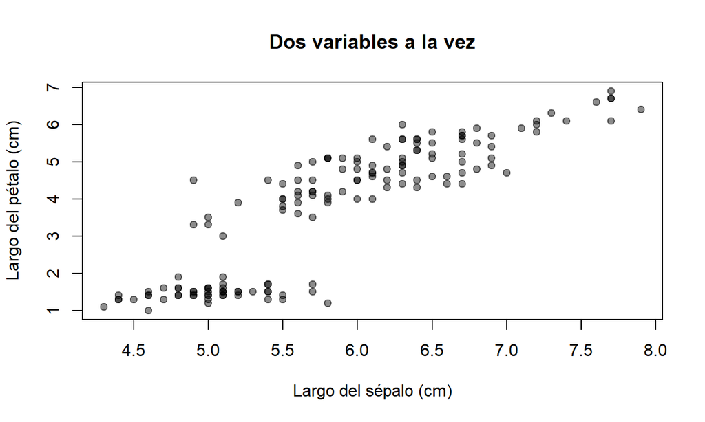

```r
data(iris)
plot(iris$Sepal.Length, iris$Petal.Length,
     pch = 19, col = rgb(0, 0, 0, 0.45),
     xlab = "Largo del sépalo (cm)", ylab = "Largo del pétalo (cm)",
     main = "Dos variables a la vez")
```

Cada punto es **una observación completa**, no un valor. Es la primera vez en el curso que un elemento gráfico representa una fila entera de la matriz $\mathbf{X}$.

## 4.2 Covarianza: la fórmula

Para dos variables $j$ y $k$ medidas sobre los mismos $n$ individuos:

$$\boxed{\;s_{jk} \;=\;
\frac{1}{n-1}\sum_{i=1}^{n}\bigl(x_{ij}-\bar x_j\bigr)\bigl(x_{ik}-\bar
x_k\bigr)\;}$$

Cómo leerla: cada sumando es el producto de **dos desviaciones respecto de la media**.

- Si las dos desviaciones tienen **el mismo signo** —ambas por encima o ambas por debajo— el producto es **positivo**.
- Si tienen **signos opuestos**, es **negativo**.

Así que $s_{jk}$ suma evidencia a favor de «van juntas» y en contra. Si gana lo positivo, la covarianza es positiva.

Y note que $s_{jj} = \dfrac{1}{n-1}\sum (x_{ij}-\bar x_j)^2 = s_j^2$: **la varianza es la covarianza de una variable consigo misma.**

```r
cov(iris$Sepal.Length, iris$Petal.Length)
```

```
#> [1] 1.274315
```

## 4.3 El problema de la covarianza, y su arreglo

La covarianza **depende de las unidades**. Si el pétalo se mide en milímetros en vez de centímetros, la covarianza se multiplica por 10 sin que la relación haya cambiado en nada.

```r
c(cm = cov(iris$Sepal.Length, iris$Petal.Length),
  mm = cov(iris$Sepal.Length, iris$Petal.Length * 10))
```

```
#>        cm        mm
#>  1.274315 12.743154
```

Por eso se divide por las dos desviaciones estándar:

$$\boxed{\;r_{jk} \;=\;
\frac{s_{jk}}{s_j\,s_k}
\;=\; \frac{\sum (x_{ij}-\bar x_j)(x_{ik}-\bar x_k)}
{\sqrt{\sum (x_{ij}-\bar x_j)^2}\;\sqrt{\sum (x_{ik}-\bar
x_k)^2}}\;}$$

**El coeficiente de correlación de Pearson.** Es adimensional, y siempre

$$-1 \;\le\; r_{jk} \;\le\; 1$$

Eso no es un capricho: es la **desigualdad de Cauchy–Schwarz** aplicada a los vectores de desviaciones. La igualdad $|r| = 1$ se alcanza sólo si un vector es múltiplo del otro — es decir, sólo si los puntos caen **exactamente sobre una recta**.

```r
c(cm = cor(iris$Sepal.Length, iris$Petal.Length),
  mm = cor(iris$Sepal.Length, iris$Petal.Length * 10))
```

```
#>        cm        mm
#> 0.8717538 0.8717538
```

**La correlación no cambió**, como debe ser.

# 5 Lo que la correlación no ve

Aquí está el punto de la sesión, y conviene resistir la tentación de adelantarlo.

El **cuarteto de Anscombe** son cuatro conjuntos de datos que vienen en R. Miremos sus resúmenes antes de graficarlos.

```r
data(anscombe)
resumen <- data.frame(
  conjunto = 1:4,
  media_x  = sapply(1:4, function(i) mean(anscombe[[paste0("x", i)]])),
  media_y  = sapply(1:4, function(i) round(mean(anscombe[[paste0("y", i)]]), 3)),
  var_x    = sapply(1:4, function(i) var(anscombe[[paste0("x", i)]])),
  var_y    = sapply(1:4, function(i) round(var(anscombe[[paste0("y", i)]]), 3)),
  r        = sapply(1:4, function(i) round(cor(anscombe[[paste0("x", i)]],
                                               anscombe[[paste0("y", i)]]), 3))
)
resumen
```

```
#>   conjunto media_x media_y var_x var_y     r
#> 1        1       9   7.501    11 4.127 0.816
#> 2        2       9   7.501    11 4.128 0.816
#> 3        3       9   7.500    11 4.123 0.816
#> 4        4       9   7.501    11 4.123 0.817
```

Mismas medias, mismas varianzas, **misma correlación**. Si sólo se miran los números, los cuatro conjuntos son indistinguibles.

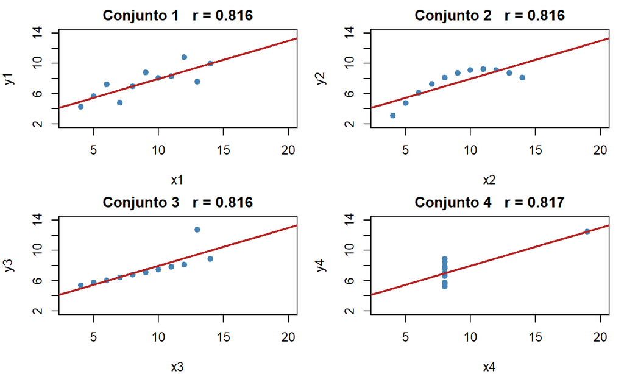

```r
par(mfrow = c(2, 2), mar = c(4, 4, 2, 1))
for (i in 1:4) {
  xi <- anscombe[[paste0("x", i)]]; yi <- anscombe[[paste0("y", i)]]
  plot(xi, yi, pch = 19, col = "steelblue", xlim = c(3, 20), ylim = c(2, 14),
       xlab = paste0("x", i), ylab = paste0("y", i),
       main = paste0("Conjunto ", i, "   r = ", round(cor(xi, yi), 3)))
  abline(lm(yi ~ xi), col = "firebrick", lwd = 2)
}
```

```r
par(mfrow = c(1, 1))
```

Cuatro nubes completamente distintas:

1. Una relación lineal razonable — el único caso donde $r$ describe bien lo que pasa.
2. Una **parábola perfecta**. La relación es exacta, y $r$ la ve igual que a la primera.
3. Una recta casi exacta **con un solo atípico** que tuerce todo.
4. Una nube vertical **y un único punto** que crea la correlación entera.

> **Lo que hay que llevarse:** $r$ mide **relación lineal**, no relación. Un $r$ bajo no significa que no haya estructura, y un $r$ alto no significa que la haya. **Siempre se grafica.**

# 6 Las tres ideas

1. La densidad kernel cambia **cajas** por **montañitas**: $\hat f_h(x)=\frac{1}{nh}\sum K\!\left(\frac{x-x_i}{h}\right)$. Elimina el origen arbitrario, pero **no elimina la decisión**: la concentra en $h$.
2. La correlación es **covarianza estandarizada**, y por eso no depende de las unidades: $r_{jk}=s_{jk}/(s_j s_k)$, con $-1\le r\le 1$ por Cauchy–Schwarz.
3. **Anscombe:** cuatro nubes distintas con los mismos cinco números. Los resúmenes numéricos nunca reemplazan al gráfico.

# 7 Lo que viene

- **Sábado 29:** los `p` gráficos de dispersión se vuelven **uno solo** — la matriz de dispersión — y la matriz de correlación $\mathbf{R}$, que es el objeto sobre el que se monta el PCA de la unidad 6.
- **Sábado 3 de octubre:** la densidad kernel **en dos dimensiones** produce contornos, y de ahí sale la **distancia de Mahalanobis**: la respuesta formal al punto atípico del sábado pasado.

> **Nota.** Este documento no se pudo tejer al escribirlo —no hay R en la máquina donde se redactó—. Téjalo una vez antes de proyectarlo: los números de `anscombe` y de `iris` son estables, pero los de la simulación dependen de `set.seed(7)`.